# Fantasy Football Long Form EDA (301 Final)

Pranav Bajaj

# Introduction

## Reading in the Datasets / Tidying

After loading in the packages, we read in the fantasy football data.

```r
library(janitor)
library(corrplot)
library(tidyverse)
```

```r
ff_data_2019 <- read_csv(file = "data/unprocessed/yearly/2019.csv") %>%
  clean_names()

ff_data_2018 <- read_csv(file = "data/unprocessed/yearly/2018.csv") %>%
               clean_names()

ff_data_2014 <- read_csv(file = "data/unprocessed/yearly/2014.csv") %>%
  clean_names()

ff_data_2009 <- read_csv(file = "data/unprocessed/yearly/2009.csv") %>%
  clean_names()
```

All of these datasets are from yearly fantasy football datasets from Fantasy Football Data Pros. Originally, when I imported each file into R (one file per year—2019, 2018, 2014, and 2009), there were many duplicate columns, and the names of the columns were ambiguous. Hence, I needed to eliminate duplicate columns and rename the existing columns to become more clear and descriptive. For most of the yearly datasets, I filtered such that the players represented needed to have above a certain threshold of fantasy points (30). This is because I wanted my visualizations to depict players who get considerable playing time. If a player is getting below 30 points on the season, they barely are in the game and their statistics may be influenced by the low playing time sample size. For example, they might have one target and one catch on the year, which would give a reception rate of 100%. However, this is misleading since the player was only thrown one ball over the entire year.

Missingness in the data was not an issue. All of the observations had values in each row, even if that value was just zero. If the player was a free agent or did not get any playing time, the position was set to zero (which is somewhat nonsensical), but I was able to filter this out in my datasets.

Additionally, for many of the datasets, I added new columns that would give meaningful information. I will explain the new columns (reception rate, completion rate, points per game) I added: Reception rate is equal to receptions over targets. Completion rate is equal to completions over attempts. And points per game is just the total fantasy points over the season divided by the number of games played. Check the code below as an example if you are interested to see how this was done. The code also shows how I selected columns specifically so no duplicates appeared.

```r
tidy_ff_data_2019 <- ff_data_2019 %>%
  #make new column
  mutate(
    rec_rate = (rec /tgt)
  ) %>%
  #make new column
  mutate(
    comp_rate = (cmp / att_9)
  ) %>%
  #make new column
  mutate(
    ppg = (fantasy_points / g)
  ) %>%
  #clearer name
  rename(
    att = att_9
  ) %>%
  #do not want repetitive columns
  select(-yds_10, -att_12, -yds_13, -passing_att,
         -yds_16, -x1)
```

For the `ff_by_pos_xxxx` datasets, I grouped by position and found the median points per game for that position. See code below for example.

```r
ff_by_pos_2019 <- tidy_ff_data_2019 %>%
  #remove position = 0
  #want players with good playign times, so filter by fantasy points
  filter(pos != 0 & fantasy_points > 30) %>%
  group_by(pos) %>%
  #new column
  summarise(
    med_ppg_by_pos_2019 = median(fantasy_points / g)
  )
```

For the `ff_over_time` datset, I created a new dataset so that I could track how the median points per game for different positions changed over time. Each row represents a position and year combination. With this dataset, we can see the median points per game for each position and year combination and compare. I had to merge different datasets from different years, and then use `pivot_longer()` so that the year and ppg would become their own columns. See code for example.

```r
#join fantasy football datasets
joined_ff <- left_join(ff_by_pos_2019, ff_by_pos_2014, by = "pos")

ff_over_time <- joined_ff %>% left_join(ff_by_pos_2009, by = "pos") %>%
  #rename columns
  rename(
    "2019" = med_ppg_by_pos_2019,
    "2014" = med_ppg_by_pos_2014,
    "2009" = med_ppg_by_pos_2009
  ) %>%
  #expand
  pivot_longer(c('2019', '2014', '2009'), names_to = "year", values_to = "ppg")
```

For a more in-depth analysis of the process or to clearly see the steps, you can visit the data_cleaning.R script. We will now read in and store the tidied data sets below.

```r
tidy_ff_data_2019 <- readRDS(file = "data/processed/tidy_ff_data_2019.rds")
tidy_ff_data_2018 <- readRDS(file = "data/processed/tidy_ff_data_2018.rds")
tidy_ff_data_2014 <- readRDS(file = "data/processed/tidy_ff_data_2014.rds")
tidy_ff_data_2009 <- readRDS(file = "data/processed/tidy_ff_data_2009.rds")
tidy_ff_data_2019_qb <- readRDS(file = "data/processed/tidy_ff_data_2019_qb.rds")
tidy_ff_data_2019_wr <- readRDS(file = "data/processed/tidy_ff_data_2019_wr.rds")
ff_by_pos_2019 <- readRDS(file = "data/processed/ff_by_pos_2019.rds")
ff_by_pos_2018 <- readRDS(file = "data/processed/ff_by_pos_2018.rds")
ff_over_time <- readRDS(file = "data/processed/ff_over_time.rds")
```

# Exploration / Body

## Investigating Distributions (Univariate)

We just want to get familiar with the *fantasy_points* variable. We are going to be working with it a lot, so let’s see its distribution. Also, let’s look at the distribution of ages of the players. Since there is only one variable in these plots, they would be considered univariate.

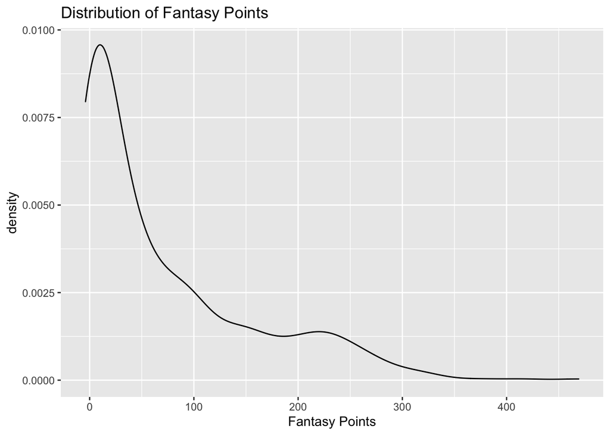

```r
#distribution of fantasy points
ggplot(tidy_ff_data_2019, aes(x = fantasy_points)) +
  geom_density() +
  #labeling
  labs(
    title = "Distribution of Fantasy Points",
    x = "Fantasy Points"
  )
```

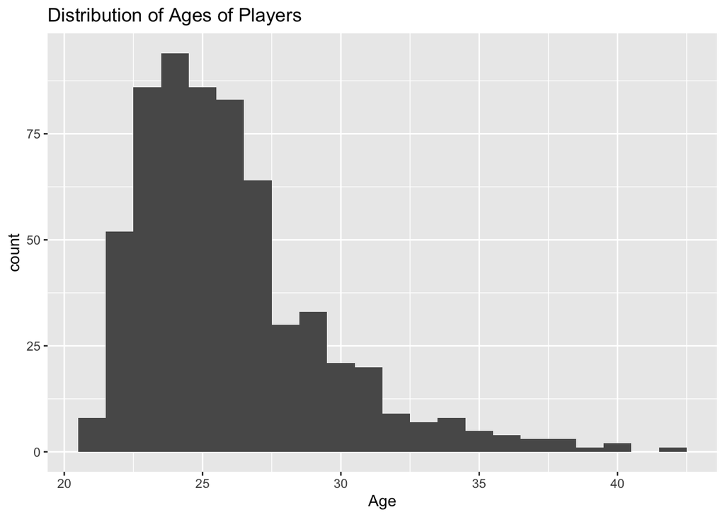

```r
ggplot(tidy_ff_data_2019, aes(x = age)) +
  geom_histogram(bins = 22) +
  #labeling
  labs(
    title = "Distribution of Ages of Players",
    x = "Age"
  )
```

We see that fantasy points are spread across a large amount of values. Most players have fantasy points between 0-100, but there are some players who have points past 300. There appears to a right skew.  
It looks like most of the players are around 25 years of age. There are not too many players in their 30s. There seem to be a few outliers who are players in their 40s. One of those outliers is certainly Tom Brady, the invincible quarterback. Again, there is a right skew.

Next, we will look at the positions and number of players of each position represented in this data.

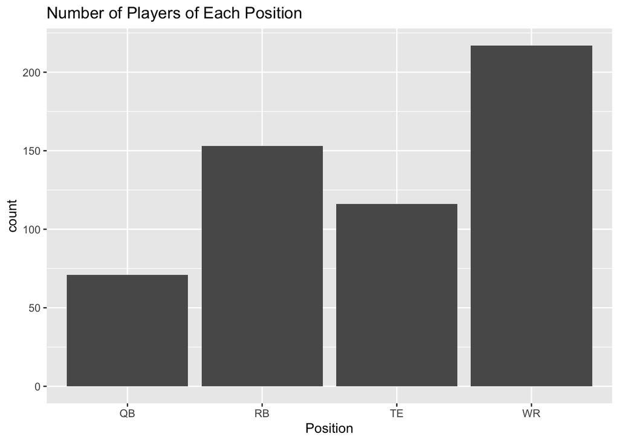

```r
tidy_ff_data_2019 %>%
  #remove position = 0
  filter(pos != 0) %>%
  ggplot() +
  #barplot
  geom_bar(mapping = aes(x = pos)) +
  #labeling
  labs(
    title = "Number of Players of Each Position",
    x = "Position"
  )
```

Most of the players represented are wide receivers, followed by running backs, followed by tide ends and then quarterbacks. This makes sense, since in a standard formation, there are multiple wide receivers on the field at one time. The same cannot be said for quarterback, running backs, or tide ends. Quarterbacks rarely get injured compared to other positions, so it would make sense that there are less quarterbacks on rosters and less quarterbacks represented in this data.

## Exploring Relationships (Mostly Bivarate + Multivariate)

Next, let’s look at how points differ based on position. We will look at two years below: 2018 and 2019. I have decided to focus on these years because they are the most recent and most related to the current NFL in 2021 (the 2020 NFL season was an anomaly due to COVID-19, so it will not be analyzed). Since there are two variables in the plots (position and points), they are considered bivariate.

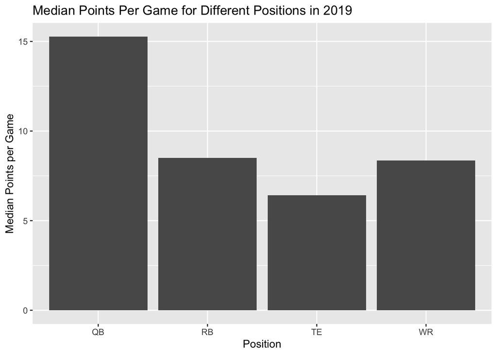

```r
ff_by_pos_2019 %>%
  ggplot(aes(x = pos, y = med_ppg_by_pos_2019)) +
  #barplot
  geom_bar(stat = "identity") +
  labs(
    title = "Median Points Per Game for Different Positions in 2019",
    x = "Position",
    y = "Median Points per Game"
  )
```

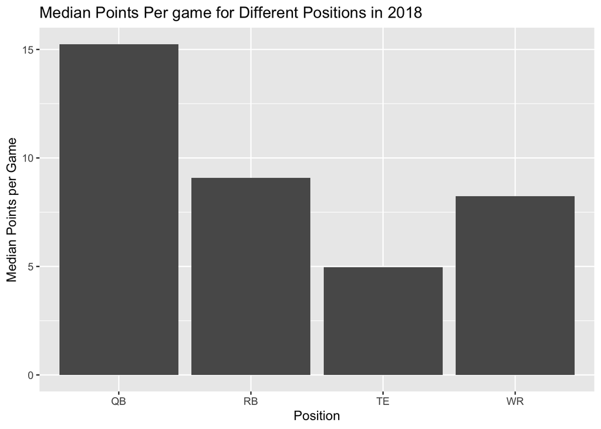

```r
ff_by_pos_2018 %>%
  ggplot(aes(x = pos, y = med_ppg_by_pos_2018)) +
  #barplot
  geom_bar(stat = "identity") +
  labs(
    title = "Median Points Per game for Different Positions in 2018",
    x = "Position",
    y = "Median Points per Game"
  )
```

In these two years, it looks like we see the same approximate trends. They are unimodal, with quarterbacks scoring the most points on average. Then we have running backs, then wide receivers, then tide ends. Obviously, in real life each position contributes to the game in different, necessary ways. However, in fantasy football, the quarterback seems to be the most productive position. This is interesting, and we should now look at if this was always the case. Have quarterbacks become more productive over time? Let’s take a look below. Also, since there are three variables, this would be considered multivariate analysis.

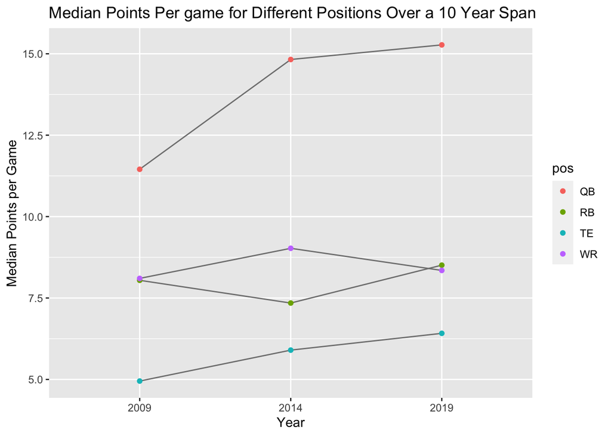

```r
ff_over_time %>%
  ggplot(mapping = aes(year, ppg)) +
  #group by position
    geom_line(aes(group = pos), color = "grey50") +
  #distinguish positions by color
    geom_point(aes(color = pos)) +
  labs(
    title = "Median Points Per game for Different Positions Over a 10 Year Span",
    x = "Year",
    y = "Median Points per Game"
  )
```

This is a very interesting graphic that lets us see trends over a ten year period. Since there are three variables, this is multivariate analysis. We see that the gap in scoring between the quarterback and other positions has increased significantly from 2009 to 2014. Both QBs (quarterbacks) and TEs (tide ends) saw point point increases from 2009 to 2014, and then from 2014 to 2019. However, the RBs (running backs) saw points decrease from 2009 to 2014, but then increase from 2014 to 2019. We see the exact opposite trend for WRs (wide receivers). Overall, football teams have been throwing the ball a lot more. Hence, it makes sense that quarterbacks would be putting up more points. Additionally, lots of these passes are short and going to running backs. This might explain why WRs see a decrease in points but RBs see an increase in points from 2014-2019.

Now, let’s dive into one year of fantasy data (2019) and see which variables are really correlated with the points. Again, we are doing 2019 because it is most recent and consequently most representative of the 2021 season. The 2020 season was an anomaly due to many unique COVID rules. Let’s start with wide receivers and look at the relationship between fantasy points and receiving yards.

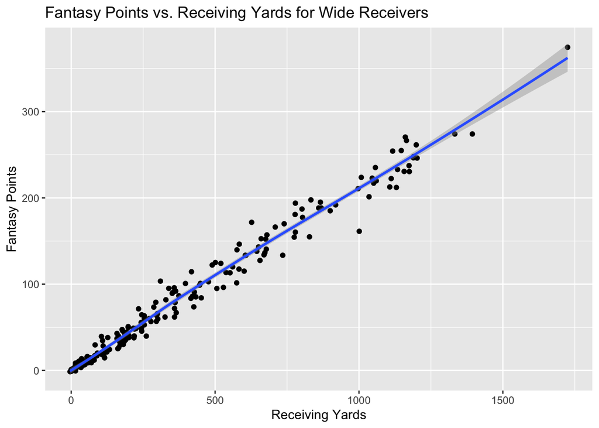

```r
tidy_ff_data_2019 %>%
  filter(pos == "WR") %>%
  ggplot(mapping = aes(x = receiving_yds, y = fantasy_points)) +
  geom_point() +
  #smoothed conditional mean
  geom_smooth() +
  labs(
    title = "Fantasy Points vs. Receiving Yards for Wide Receivers",
    x = "Receiving Yards",
    y = "Fantasy Points"
  )
```

This looks to be a very strong positive relationship, as we can clearly draw a positively sloped line that runs closely through the data points. Hence, receiving yards is very correlated to fantasy points, which is what we would expect considering receivers are rewarded points for each yard caught. What about reception rate? We should facet based on position, since each position generally has a different type of throw thrown at them.

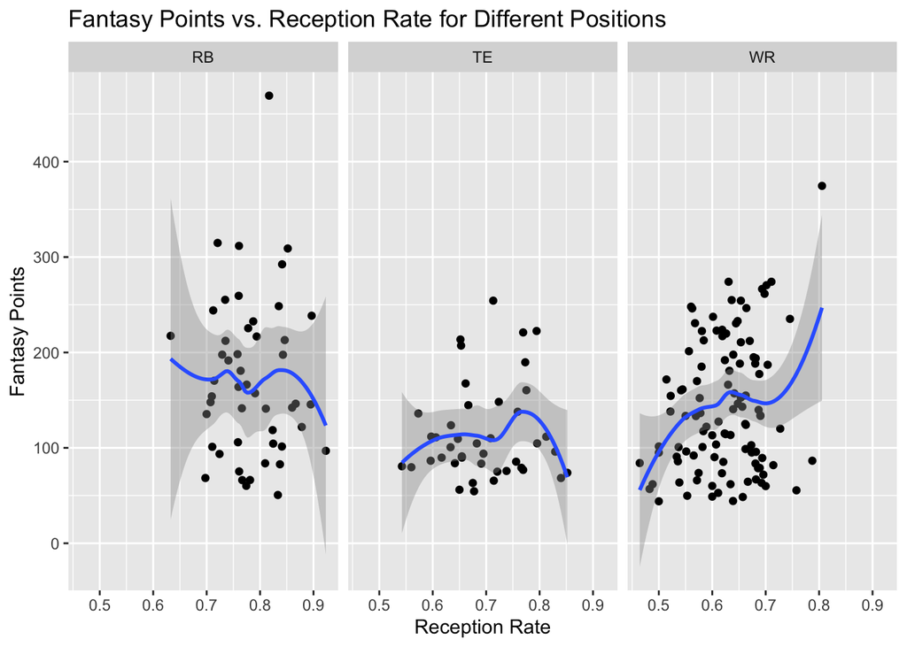

```r
tidy_ff_data_2019 %>%
  #using overall dataset because want many positions
  #want players with a good amount of receptions
  filter(rec >= 20) %>%
  ggplot(mapping = aes(x = rec_rate, y = fantasy_points)) +
  geom_point() +
  geom_smooth(method = loess) +
  #different cells for different positions
  facet_wrap(~pos) +
  labs(
    title = "Fantasy Points vs. Reception Rate for Different Positions",
    x = "Reception Rate",
    y = "Fantasy Points"
  )
```

This is pretty interesting. The first thing I notice is that WRs have a lower average reception rate than both RBs and TEs. Most of the points on the plot for WRs are between .5 and .7 on the x-axis of *rec_rate*. Most of the points on the plot for RBs are between .7 and .9 of *rec_rate*. And most of the points on the plot for TEs are between a wider range of .55 and .85 of *rec_rate*. This all makes sense, since running backs catch a lot of short-yardage screens, which are easier to catch since there is low coverage and a quick, short pass. Wide receivers generally catch farther balls, where there is more coverage and they have a lower probability of catching since it is a farther distance. Tide ends do a mix of short and long passes, which explains why its data trends are in-between those of the WRs and RBs.  
For running backs and tide ends, there seems to be low correlation between reception rate and fantasy points. There doesn’t seems to be a clear trend in points based on the lines. For wide receivers, there does seem to be a stronger positive correlation between reception rate and fantasy points. This might be because wide receivers catch balls from farther throws, so a higher success rate could translate to a lot more points. For example, if running backs are just given 1-yard throws, reception rate wouldn’t really matter since each throw on average would only give the running back a few points. But if wide receivers are given 30-yards throws, reception rate might matter since more catches would mean lots more points.

This is interesting. I bet there is a closer relationship between fantasy points and targets. Let us check below.

To review, a target is whenever a player is thrown the ball. It counts as a target whether the player catches the ball or not. A reception is when the ball is actually caught.

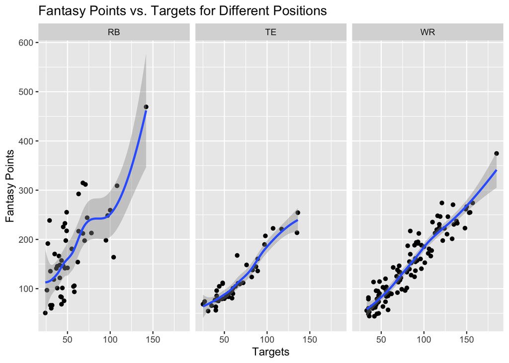

```r
tidy_ff_data_2019 %>%
  filter(rec >= 20) %>%
  #want players with a good amount of receptions (get good playing time)
  ggplot(mapping = aes(x = tgt, y = fantasy_points)) +
  geom_point() +
  #smoothed conditional mean
  geom_smooth() +
  #distinguish by position
  facet_wrap(~pos) +
  labs(
    title = "Fantasy Points vs. Targets for Different Positions",
    x = "Targets",
    y = "Fantasy Points"
  )
```

Yes, it looks like I was right. Across all positions, we see a clear positive relationship between targets and fantasy points. This makes sense, since more targets means more opportunities to score points. Let’s now look closer at running backs.

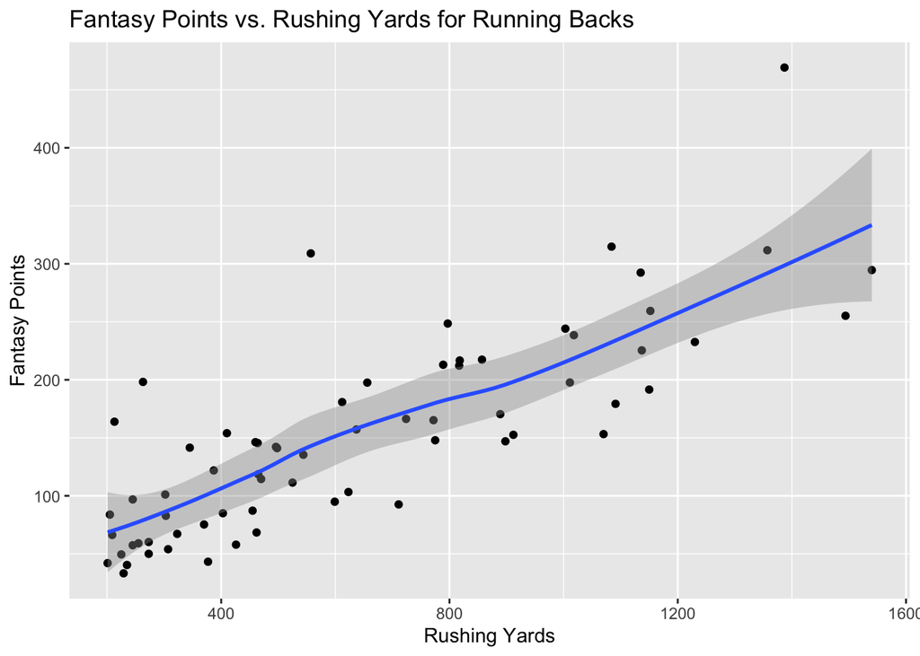

```r
tidy_ff_data_2019 %>%
  #filter by running backs
  filter(pos == "RB") %>%
  #want starters
  filter(rushing_yds > 200) %>%
  ggplot(mapping = aes(x = rushing_yds, y = fantasy_points)) +
  geom_point() +
  geom_smooth() +
  labs(
    title = "Fantasy Points vs. Rushing Yards for Running Backs",
    x = "Rushing Yards",
    y = "Fantasy Points"
  )
```

As expected there is a clear relationship between running yards and fantasy points. There is a positive relationship between the variables. As running yards increases, fantasy points increases. The positive line that runs closely throught he points shows this as well. Let’s now look at quarterbacks. We would expect to see a positive relationship between passing yards and fantasy points.

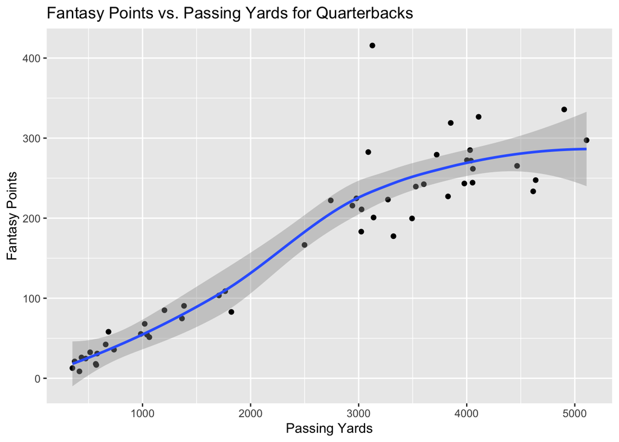

```r
tidy_ff_data_2019_qb %>%
  ggplot(mapping = aes(x = passing_yds, y = fantasy_points)) +
  geom_point() +
  geom_smooth() +
  labs(
    title = "Fantasy Points vs. Passing Yards for Quarterbacks",
    x = "Passing Yards",
    y = "Fantasy Points"
  )
```

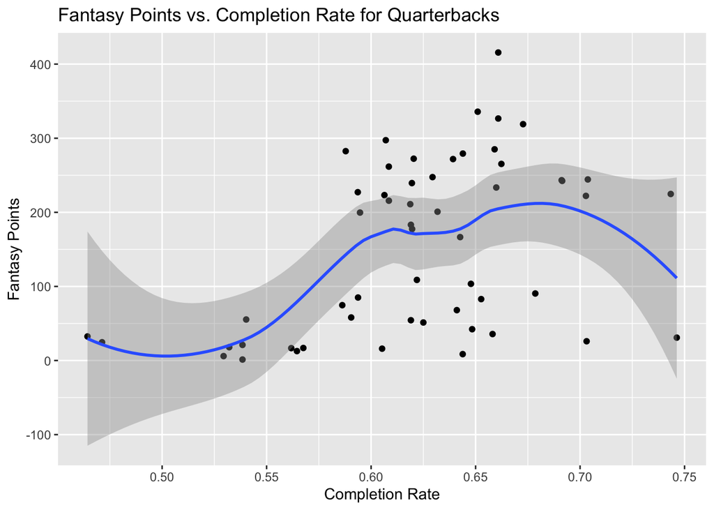

```r
#completion rate isn't in our qb subset, so use overall dataset
tidy_ff_data_2019 %>%
  #want starters who have lots of attempts
  filter(att >= 30) %>%
  ggplot(mapping = aes(x = comp_rate, y = fantasy_points)) +
  geom_point() +
  geom_smooth() +
  labs(
    title = "Fantasy Points vs. Completion Rate for Quarterbacks",
    x = "Completion Rate",
    y = "Fantasy Points"
  )
```

As expected, there isn’t a clear correlation between completion rate of throws and fantasy points. If a quarterback converts all their throws but only tries for 1-yard throws, this would mean a high completion rate with low fantasy points. Some quarterbacks do only try for short passes, so this shows why the correlation is apparently low. What we do see is that most of the points on the plot are within .6 and .7 on the x-axis, so this is probably where the average completion rate for quarterbacks in the NFL lies (60-70%). Now let’s looks at volume through pass attempts vs. fantasy points.

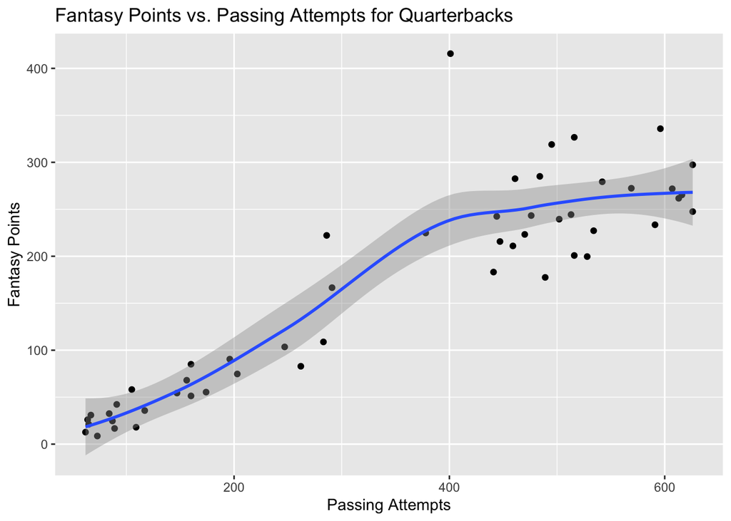

```r
#now use qb subset data because att is present
tidy_ff_data_2019_qb %>%
  ggplot(mapping = aes(x = att, y = fantasy_points)) +
  geom_point() +
  #easier to see trend with the line
  geom_smooth() +
  labs(
    title = "Fantasy Points vs. Passing Attempts for Quarterbacks",
    x = "Passing Attempts",
    y = "Fantasy Points"
  )
```

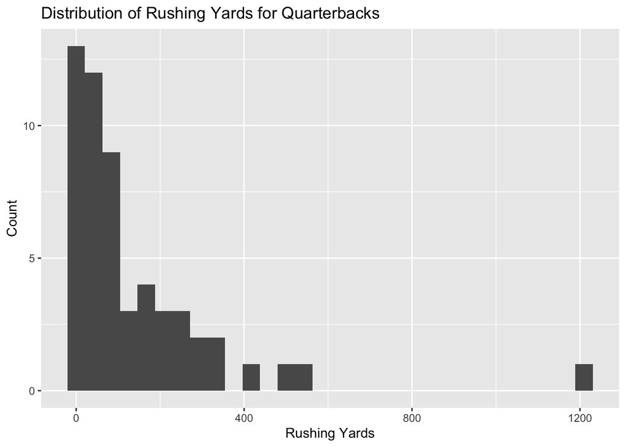

```r
#use overall dataset because rushing yards isn't in the qb subset
tidy_ff_data_2019 %>%
  #want consistent starters
  filter(att >= 30) %>%
  filter(pos == "QB") %>%
  ggplot(aes(x = rushing_yds)) +
  geom_histogram() +
  labs(
    title = "Distribution of Rushing Yards for Quarterbacks",
    x = "Rushing Yards",
    y = "Count"
  )
```

This confirms what we hypothesized. We see one player who has way more rushing yards (1200) than everyone else, who mostly have yards below 400. This explains how Lamar Jackson can be top fantasy scorer for quarterbacks without throwing often. We can confirm that Lamar Jackson was the top fantasy quarterback below.

```r
#use overall dataset since player names are not in the qb subset
tidy_ff_data_2019 %>%
  filter(pos == "QB") %>%
  arrange(desc(fantasy_points)) %>%
  select(player, fantasy_points) %>%
  head(1)
```

```
## # A tibble: 1 × 2
##   player        fantasy_points
##   <chr>                  <dbl>
## 1 Lamar Jackson           416.
```

Now we can confirm that Lamar Jackson was the fantasy quarterback with the most rushing yards below as well.

```r
#use overall dataset since player names are not in the qb subset
tidy_ff_data_2019 %>%
  filter(pos == "QB") %>%
  arrange(desc(rushing_yds)) %>%
  select(player, rushing_yds, fantasy_points) %>%
  head(1)
```

```
## # A tibble: 1 × 3
##   player        rushing_yds fantasy_points
##   <chr>               <dbl>          <dbl>
## 1 Lamar Jackson        1206           416.
```

While we are on the topic of quarterbacks, we should look at the relationship between fantasy points an interceptions.

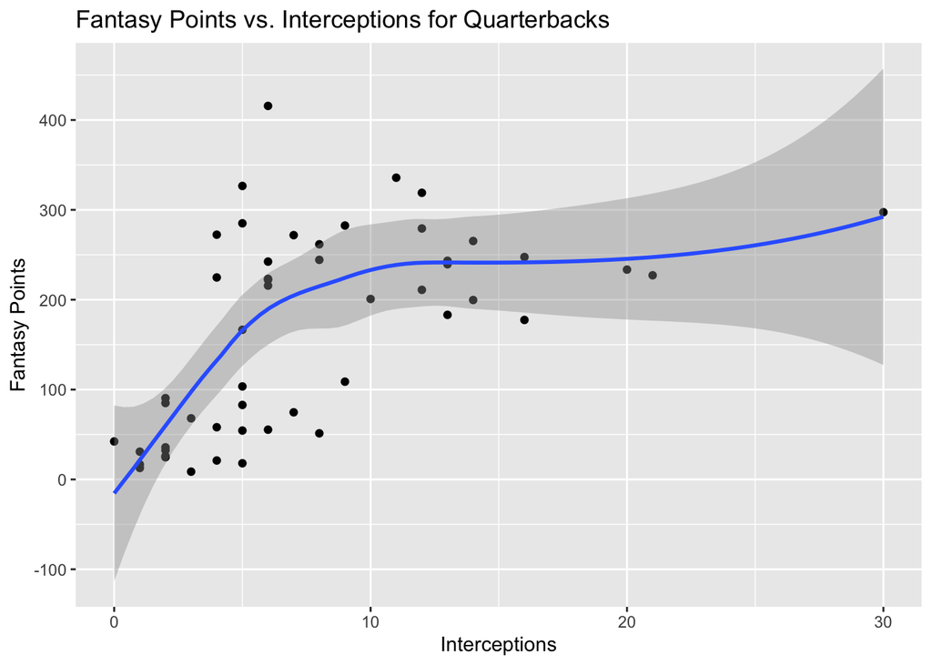

```r
#use qb subset because int is included
tidy_ff_data_2019_qb %>%
  ggplot(mapping = aes(x = int, y = fantasy_points)) +
  geom_point() +
  geom_smooth() +
  labs(
    title = "Fantasy Points vs. Interceptions for Quarterbacks",
    x = "Interceptions",
    y = "Fantasy Points"
  )
```

We saw a positive, partially linear relationship between interceptions and fantasy points for quarterbacks. The highest score threw just over 5 interceptions, which is a relatively low number. This is because the highest scorer, Lamar Jackson, gets most of his points from running and does not throw that often, as previously illustrated. We also see one player who has thrown the most interceptions by far (30), but is not even in the top three of scorers. Hence, this player would also be an outlier.